# Dimensionality Reduction Technique

Shweta Goswami

1-12-2018

# Dimensionality Reduction Technique

### **1. Data Overview**

```
## 'data.frame':    155 obs. of  8 variables:
##  $ Edu2.FM  : num  1.007 0.997 0.983 0.989 0.969 ...
##  $ Labo.FM  : num  0.891 0.819 0.825 0.884 0.829 ...
##  $ Edu.Exp  : num  17.5 20.2 15.8 18.7 17.9 16.5 18.6 16.5 15.9 19.2 ...
##  $ Life.Exp : num  81.6 82.4 83 80.2 81.6 80.9 80.9 79.1 82 81.8 ...
##  $ GNI      : int  64992 42261 56431 44025 45435 43919 39568 52947 42155 32689 ...
##  $ Mat.Mor  : int  4 6 6 5 6 7 9 28 11 8 ...
##  $ Ado.Birth: num  7.8 12.1 1.9 5.1 6.2 3.8 8.2 31 14.5 25.3 ...
##  $ Parli.F  : num  39.6 30.5 28.5 38 36.9 36.9 19.9 19.4 28.2 31.4 ...
```

```
## [1] 155   8
```

- The data used in analysis was based on human development report by United Nations Development Programme. The Human Development and Gender Inequality indices will be analysed. The original dataset has combined indicators from different parts of the world. Out of them, some variables are selected for the analysis. The indicators of Human development index are Gross National Income per capita, Life expectancy at birth, Maternal mortality ratio, Adolescent birth rate and Expected years of schooling. The indicators for Gender Inequality Index are are Percetange of female representatives in parliament, Proportion of males and females with at least secondary education and Proportion of males and females in the labour force. The proportion of males and females in education and labor force variables has been modified. The first one is the the ratio of Female and Male populations with secondary education in each country. (i.e. edu2F / edu2M). The second one is the ratio of labour force participation of females and males in each country (i.e. labF / labM).
- The current dataset has 155 observations of 8 variables.
- More information about the dataset can be found at http://hdr.undp.org/en/content/human-development-index-hdi

**a. Summary of the data**

```
##     Edu2.FM          Labo.FM          Edu.Exp         Life.Exp
##  Min.   :0.1717   Min.   :0.1857   Min.   : 5.40   Min.   :49.00
##  1st Qu.:0.7264   1st Qu.:0.5984   1st Qu.:11.25   1st Qu.:66.30
##  Median :0.9375   Median :0.7535   Median :13.50   Median :74.20
##  Mean   :0.8529   Mean   :0.7074   Mean   :13.18   Mean   :71.65
##  3rd Qu.:0.9968   3rd Qu.:0.8535   3rd Qu.:15.20   3rd Qu.:77.25
##  Max.   :1.4967   Max.   :1.0380   Max.   :20.20   Max.   :83.50
##       GNI            Mat.Mor         Ado.Birth         Parli.F
##  Min.   :   581   Min.   :   1.0   Min.   :  0.60   Min.   : 0.00
##  1st Qu.:  4198   1st Qu.:  11.5   1st Qu.: 12.65   1st Qu.:12.40
##  Median : 12040   Median :  49.0   Median : 33.60   Median :19.30
##  Mean   : 17628   Mean   : 149.1   Mean   : 47.16   Mean   :20.91
##  3rd Qu.: 24512   3rd Qu.: 190.0   3rd Qu.: 71.95   3rd Qu.:27.95
##  Max.   :123124   Max.   :1100.0   Max.   :204.80   Max.   :57.50
```

- The minimum and maximum value for ratio of female to male rates with at least secondary education are 0.17 and 1.5 resp. The minimum and maximum value of Labour force participation rate, female-male ratio are 0.18 and 1.04 resp. The minimum value of female-male shares in secondary education and labor force shows the limitations of women to access the basic rights to have atleast secondary education and employment in some of the countries in the current dataset. The maximum number of maternal mortality rate is 1100 (deaths per 100,000 live births). The minimum value of GNI per capita is 581 which seems to be very low in terms of nation and human development.

### **2. Graphical overview of the data and relationship between variables**

**a. Graphical Overview using corrplot**

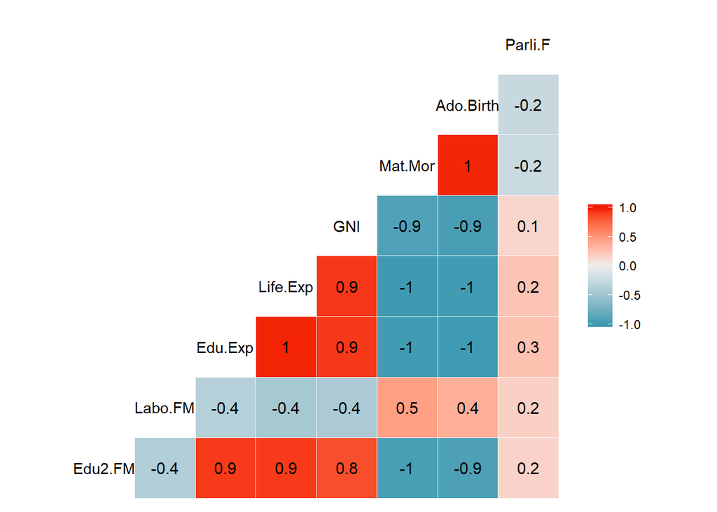

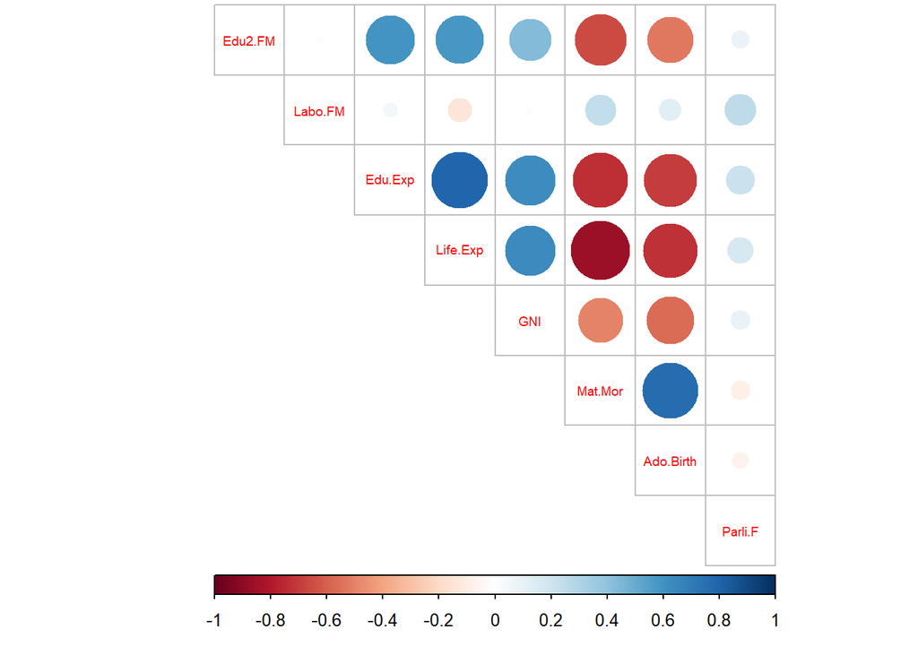

- There seems to be perfect negative corelation (one variable increases as the other decreases) between ratio of female to male rates with at least secondary education and maternal mortality rate. Similarly, negative corelation is present with the variables expected years of schooling and maternal mortality rate. The positive corelation is found between ratio of female to male rates with at least secondary education and life expectancy. Women who are more educated seems to have high life expectancy.

### **3. Principal component analysis (PCA)**

**a. Principal component analysis (PCA) on the non-standardized human data**

```
## Standard deviations (1, .., p=8):
## [1] 1.854416e+04 1.855219e+02 2.518701e+01 1.145441e+01 3.766241e+00
## [6] 1.565912e+00 1.912052e-01 1.591112e-01
##
## Rotation (n x k) = (8 x 8):
##                     PC1           PC2           PC3           PC4
## Edu2.FM   -5.607472e-06  0.0006713951 -3.412027e-05 -2.736326e-04
## Labo.FM    2.331945e-07 -0.0002819357  5.302884e-04 -4.692578e-03
## Edu.Exp   -9.562910e-05  0.0075529759  1.427664e-02 -3.313505e-02
## Life.Exp  -2.815823e-04  0.0283150248  1.294971e-02 -6.752684e-02
## GNI       -9.999832e-01 -0.0057723054 -5.156742e-04  4.932889e-05
## Mat.Mor    5.655734e-03 -0.9916320120  1.260302e-01 -6.100534e-03
## Ado.Birth  1.233961e-03 -0.1255502723 -9.918113e-01  5.301595e-03
## Parli.F   -5.526460e-05  0.0032317269 -7.398331e-03 -9.971232e-01
##                     PC5           PC6           PC7           PC8
## Edu2.FM   -0.0022935252  2.180183e-02  6.998623e-01  7.139410e-01
## Labo.FM    0.0022190154  3.264423e-02  7.132267e-01 -7.001533e-01
## Edu.Exp    0.1431180282  9.882477e-01 -3.826887e-02  7.776451e-03
## Life.Exp   0.9865644425 -1.453515e-01  5.380452e-03  2.281723e-03
## GNI       -0.0001135863 -2.711698e-05 -8.075191e-07 -1.176762e-06
## Mat.Mor    0.0266373214  1.695203e-03  1.355518e-04  8.371934e-04
## Ado.Birth  0.0188618600  1.273198e-02 -8.641234e-05 -1.707885e-04
## Parli.F   -0.0716401914 -2.309896e-02 -2.642548e-03  2.680113e-03
```

```
## Importance of components:
##                              PC1      PC2   PC3   PC4   PC5   PC6    PC7
## Standard deviation     1.854e+04 185.5219 25.19 11.45 3.766 1.566 0.1912
## Proportion of Variance 9.999e-01   0.0001  0.00  0.00 0.000 0.000 0.0000
## Cumulative Proportion  9.999e-01   1.0000  1.00  1.00 1.000 1.000 1.0000
##                           PC8
## Standard deviation     0.1591
## Proportion of Variance 0.0000
## Cumulative Proportion  1.0000
```

**b. Biplot of non-standardized human data**

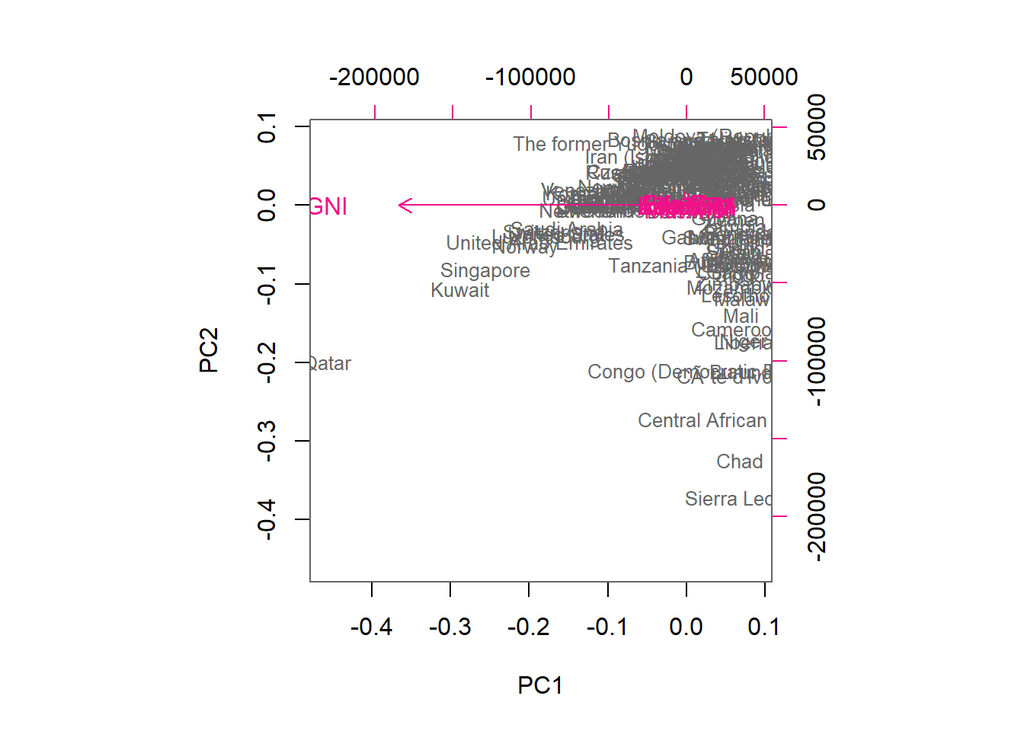

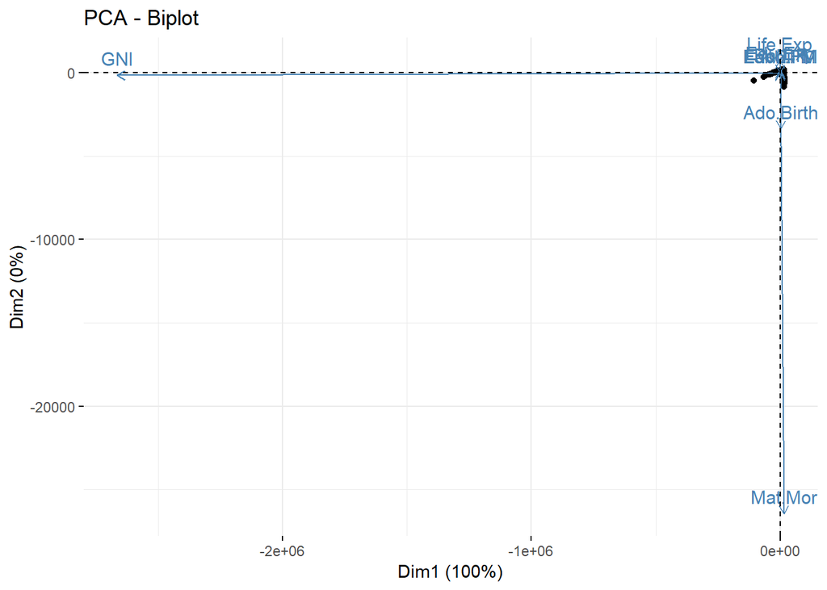

**c. Screeplot of non-standardized human data**

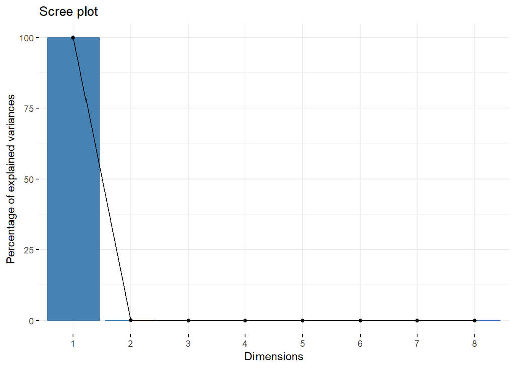

**d. Principal component analysis (PCA) of standardized human data.**

```
##     Edu2.FM           Labo.FM           Edu.Exp           Life.Exp
##  Min.   :-2.8189   Min.   :-2.6247   Min.   :-2.7378   Min.   :-2.7188
##  1st Qu.:-0.5233   1st Qu.:-0.5484   1st Qu.:-0.6782   1st Qu.:-0.6425
##  Median : 0.3503   Median : 0.2316   Median : 0.1140   Median : 0.3056
##  Mean   : 0.0000   Mean   : 0.0000   Mean   : 0.0000   Mean   : 0.0000
##  3rd Qu.: 0.5958   3rd Qu.: 0.7350   3rd Qu.: 0.7126   3rd Qu.: 0.6717
##  Max.   : 2.6646   Max.   : 1.6632   Max.   : 2.4730   Max.   : 1.4218
##       GNI             Mat.Mor          Ado.Birth          Parli.F
##  Min.   :-0.9193   Min.   :-0.6992   Min.   :-1.1325   Min.   :-1.8203
##  1st Qu.:-0.7243   1st Qu.:-0.6496   1st Qu.:-0.8394   1st Qu.:-0.7409
##  Median :-0.3013   Median :-0.4726   Median :-0.3298   Median :-0.1403
##  Mean   : 0.0000   Mean   : 0.0000   Mean   : 0.0000   Mean   : 0.0000
##  3rd Qu.: 0.3712   3rd Qu.: 0.1932   3rd Qu.: 0.6030   3rd Qu.: 0.6127
##  Max.   : 5.6890   Max.   : 4.4899   Max.   : 3.8344   Max.   : 3.1850
```

```
## Importance of components:
##                           PC1    PC2     PC3     PC4     PC5     PC6
## Standard deviation     2.0708 1.1397 0.87505 0.77886 0.66196 0.53631
## Proportion of Variance 0.5361 0.1624 0.09571 0.07583 0.05477 0.03595
## Cumulative Proportion  0.5361 0.6984 0.79413 0.86996 0.92473 0.96069
##                            PC7     PC8
## Standard deviation     0.45900 0.32224
## Proportion of Variance 0.02634 0.01298
## Cumulative Proportion  0.98702 1.00000
```

```
##  PC1  PC2  PC3  PC4  PC5  PC6  PC7  PC8
## 53.6 16.2  9.6  7.6  5.5  3.6  2.6  1.3
```

**e. Biplot and screeplot of standardized human data**

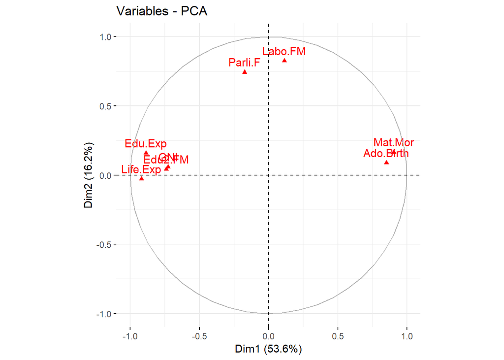

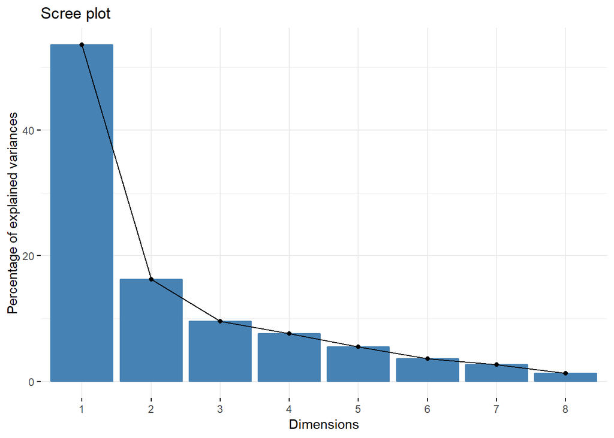

**g. Interpretation of biplot of standardized datatset:**

- The biplot shows the first two principal component scores. Maternal mortality rate and adolescent birth rate seems to be closely related and pointing towards the least development countries, for instance, Sierra Leone. Similarly, percetange of female representatives in parliament and ratio of female-male shares in labor force participation appears to be closely related and pointing towards countries like Tanzania. Expected years of schooling, Life expectancy at birth, ratio of female-male shares in secondary education are closely related and pointing towards developed countries.

**h. Caption (replacing PC1 and PC2) of the standardized plot**

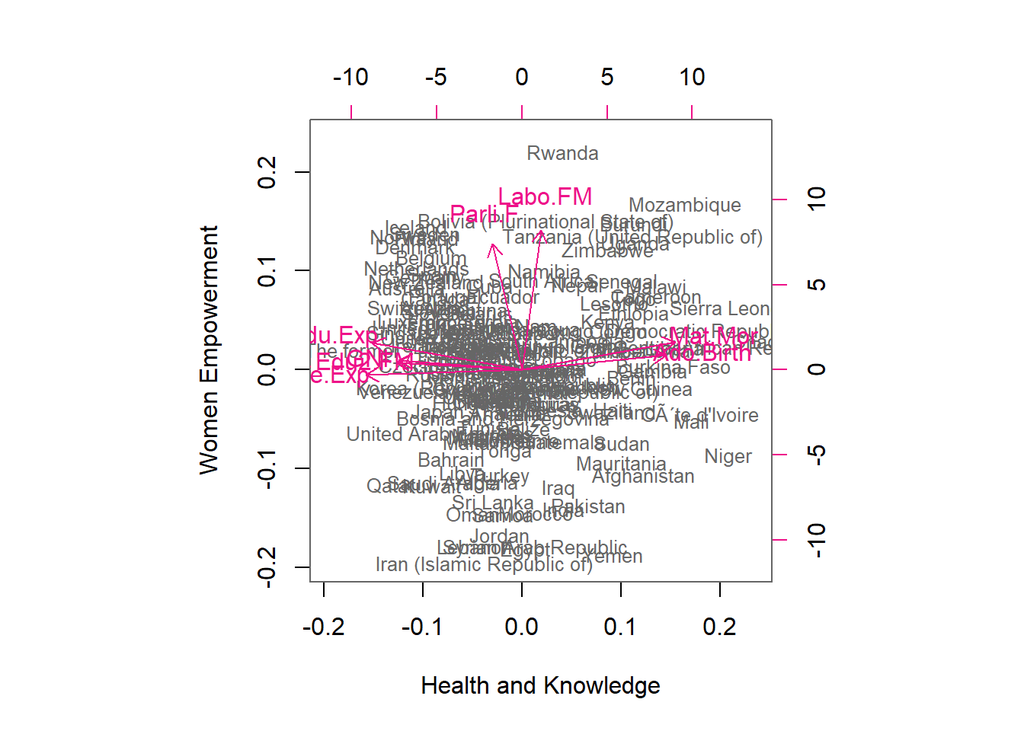

**i. Cos2 : quality of the representation for variables on the factor map**

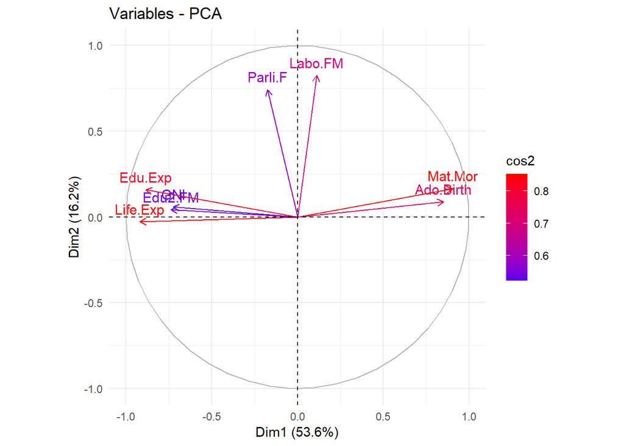

- Showing the most contributing indicators in explaining the variations retained by the principal components.

### **4. Personal interpretations of the first two principal component dimensions based on the biplot**

**a. Selecting the top 3 contributing variables**

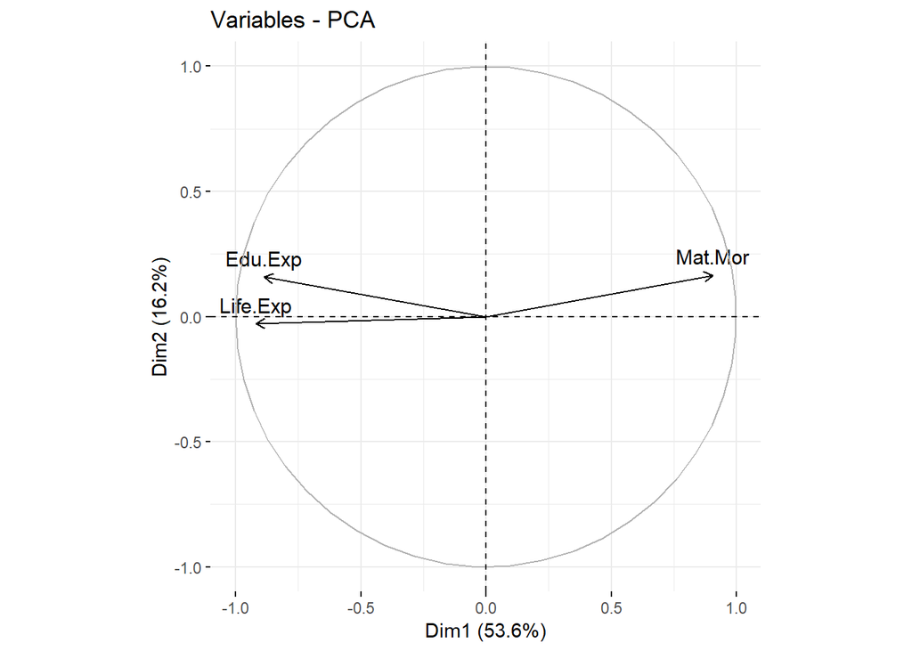

**b. Contributions of variables on PC1**

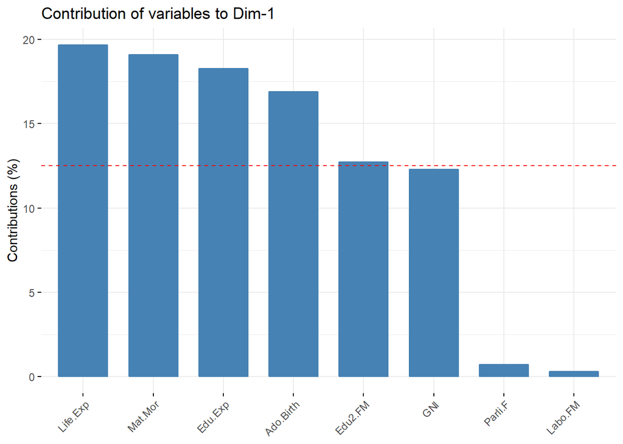

**c. Contributions of variables on PC2**

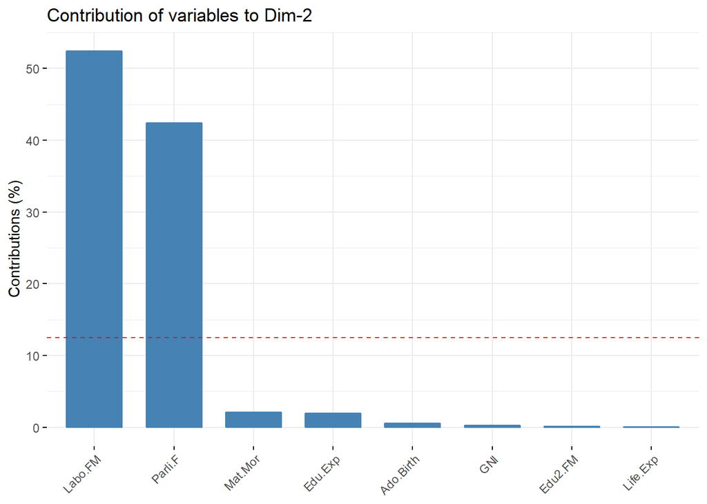

### **5. Tea dataset**

```
## 'data.frame':    300 obs. of  36 variables:
##  $ breakfast       : Factor w/ 2 levels "breakfast","Not.breakfast": 1 1 2 2 1 2 1 2 1 1 ...
##  $ tea.time        : Factor w/ 2 levels "Not.tea time",..: 1 1 2 1 1 1 2 2 2 1 ...
##  $ evening         : Factor w/ 2 levels "evening","Not.evening": 2 2 1 2 1 2 2 1 2 1 ...
##  $ lunch           : Factor w/ 2 levels "lunch","Not.lunch": 2 2 2 2 2 2 2 2 2 2 ...
##  $ dinner          : Factor w/ 2 levels "dinner","Not.dinner": 2 2 1 1 2 1 2 2 2 2 ...
##  $ always          : Factor w/ 2 levels "always","Not.always": 2 2 2 2 1 2 2 2 2 2 ...
##  $ home            : Factor w/ 2 levels "home","Not.home": 1 1 1 1 1 1 1 1 1 1 ...
##  $ work            : Factor w/ 2 levels "Not.work","work": 1 1 2 1 1 1 1 1 1 1 ...
##  $ tearoom         : Factor w/ 2 levels "Not.tearoom",..: 1 1 1 1 1 1 1 1 1 2 ...
##  $ friends         : Factor w/ 2 levels "friends","Not.friends": 2 2 1 2 2 2 1 2 2 2 ...
##  $ resto           : Factor w/ 2 levels "Not.resto","resto": 1 1 2 1 1 1 1 1 1 1 ...
##  $ pub             : Factor w/ 2 levels "Not.pub","pub": 1 1 1 1 1 1 1 1 1 1 ...
##  $ Tea             : Factor w/ 3 levels "black","Earl Grey",..: 1 1 2 2 2 2 2 1 2 1 ...
##  $ How             : Factor w/ 4 levels "alone","lemon",..: 1 3 1 1 1 1 1 3 3 1 ...
```

[output cut: 22 more lines]

```
## [1] 300  36
```

**a. Structure and the dimensions of the data**

- The tea dataset has been loaded from the package Factominer. The original dataset has 300 obs. of 36 variables. The variables included in the dataset are breakfast, teatime, always, home, work, price, diuretic etc.
- 300 individuals who participated in the survey were asked about how they drink tea (18 questions), what are their product’s perception (12 questions) and some personal details (4 questions).

```
##         Tea         How             healthy         sugar
##  black    : 74   alone:195   healthy    :210   No.sugar:155
##  Earl Grey:193   lemon: 33   Not.healthy: 90   sugar   :145
##  green    : 33   milk : 63
##                  other:  9
##                   where           lunch
##  chain store         :192   lunch    : 44
##  chain store+tea shop: 78   Not.lunch:256
##  tea shop            : 30
##
```

```
## 'data.frame':    300 obs. of  6 variables:
##  $ Tea    : Factor w/ 3 levels "black","Earl Grey",..: 1 1 2 2 2 2 2 1 2 1 ...
##  $ How    : Factor w/ 4 levels "alone","lemon",..: 1 3 1 1 1 1 1 3 3 1 ...
##  $ healthy: Factor w/ 2 levels "healthy","Not.healthy": 1 1 1 1 2 1 1 1 2 1 ...
##  $ sugar  : Factor w/ 2 levels "No.sugar","sugar": 2 1 1 2 1 1 1 1 1 1 ...
##  $ where  : Factor w/ 3 levels "chain store",..: 1 1 1 1 1 1 1 1 2 2 ...
##  $ lunch  : Factor w/ 2 levels "lunch","Not.lunch": 2 2 2 2 2 2 2 2 2 2 ...
```

- For the current analysis, some of the variables from the tea dataset has been selected which are ‘tea’, ‘How’, ‘healthy’, ‘sugar’, ‘where’ and ‘lunch’. All the variables are categorical.
- It has 300 obs. of 6 variables.

**b. Visualize the dataset**

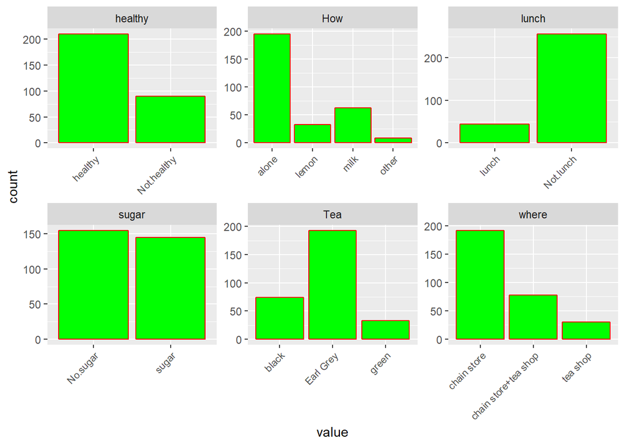

Most of the tea consumers were: * Healthy. * Preferred Earl grey tea * Preferred tea alone without any addition of milk, lemon and other stuff * Preferred sipping tea other than the lunch time * Preferred chain store.

### **6. Multiple Correspondence Analysis on the tea data**

```
##
## Call:
## MCA(X = tea_time, graph = FALSE)
##
##
## Eigenvalues
##                        Dim.1   Dim.2   Dim.3   Dim.4   Dim.5   Dim.6
## Variance               0.231   0.223   0.200   0.179   0.169   0.163
## % of var.             13.889  13.404  12.013  10.725  10.120   9.773
## Cumulative % of var.  13.889  27.293  39.306  50.031  60.151  69.924
##                        Dim.7   Dim.8   Dim.9  Dim.10
## Variance               0.140   0.138   0.120   0.103
## % of var.              8.402   8.309   7.180   6.185
## Cumulative % of var.  78.326  86.635  93.815 100.000
##
## Individuals (the 10 first)
##                Dim.1    ctr   cos2    Dim.2    ctr   cos2    Dim.3    ctr
## 1           |  0.199  0.057  0.041 | -0.192  0.055  0.038 | -0.285  0.135
## 2           |  0.612  0.539  0.252 | -0.102  0.016  0.007 | -0.376  0.236
## 3           |  0.039  0.002  0.003 | -0.309  0.143  0.180 | -0.239  0.095
## 4           | -0.333  0.159  0.200 | -0.074  0.008  0.010 | -0.229  0.087
## 5           | -0.289  0.121  0.099 | -0.300  0.134  0.106 | -0.346  0.199
## 6           |  0.039  0.002  0.003 | -0.309  0.143  0.180 | -0.239  0.095
## 7           |  0.039  0.002  0.003 | -0.309  0.143  0.180 | -0.239  0.095
## 8           |  0.612  0.539  0.252 | -0.102  0.016  0.007 | -0.376  0.236
## 9           |  0.015  0.000  0.000 |  0.506  0.382  0.145 | -0.186  0.057
## 10          |  0.834  1.002  0.524 |  0.053  0.004  0.002 | -0.054  0.005
##               cos2
## 1            0.084 |
## 2            0.095 |
## 3            0.107 |
## 4            0.094 |
## 5            0.141 |
## 6            0.107 |
## 7            0.107 |
## 8            0.095 |
## 9            0.019 |
## 10           0.002 |
##
## Categories (the 10 first)
```

[output cut: 16 more lines]

```
## lemon         7.109 |   1.838  30.931   0.417  11.173 |
## milk          4.392 |  -0.375   2.453   0.037  -3.339 |
## other         4.770 |  -0.701   1.226   0.015  -2.131 |
## healthy      -0.213 |   0.086   0.431   0.017   2.272 |
## Not.healthy   0.213 |  -0.201   1.006   0.017  -2.272 |
## No.sugar     -5.772 |  -0.014   0.008   0.000  -0.245 |
##
## Categorical variables (eta2)
##               Dim.1 Dim.2 Dim.3
## Tea         | 0.421 0.346 0.138 |
## How         | 0.340 0.395 0.432 |
## healthy     | 0.188 0.000 0.017 |
## sugar       | 0.287 0.111 0.000 |
## where       | 0.107 0.420 0.604 |
## lunch       | 0.044 0.069 0.010 |
```

**a. Visualize MCA**

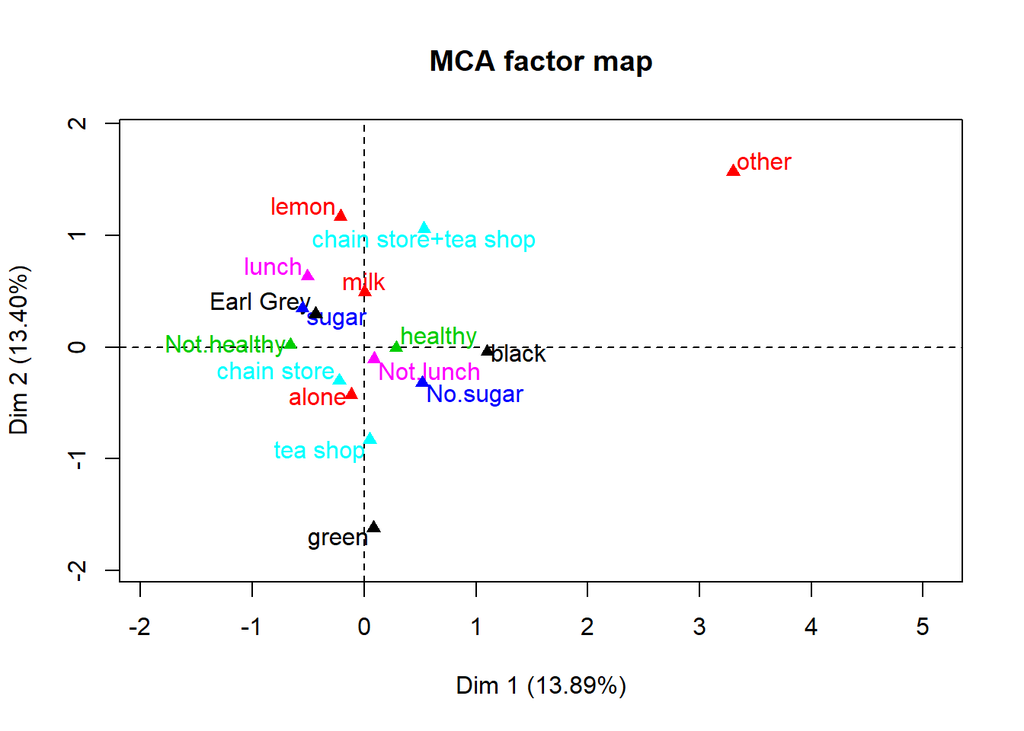

- The multiple correspondence analysis helps in summarizing and visualizing dataset containing more than two categorical variables.
- Dim 1 shows 14% of the variation and Dim 2 shows 13% of the variation which is very low.
- The intersection of two dashed lines is the origin. The far the variables are from the origin, the more discriminating they are, for instance, other is a highly discriminating attribute.
- The variables closer to the origin are less discriminating, For instance, chain store and sugar probably shares similar repo.
- As shown in the plot, the earl grey consumers who put sugar in their tea seems to be unhealthy, whereas the consumers who preferred sipping black tea other than the lunch time and without sugar seems to be healthy.

**b. Using the function fviz_mca_var() to visualize variable categories**

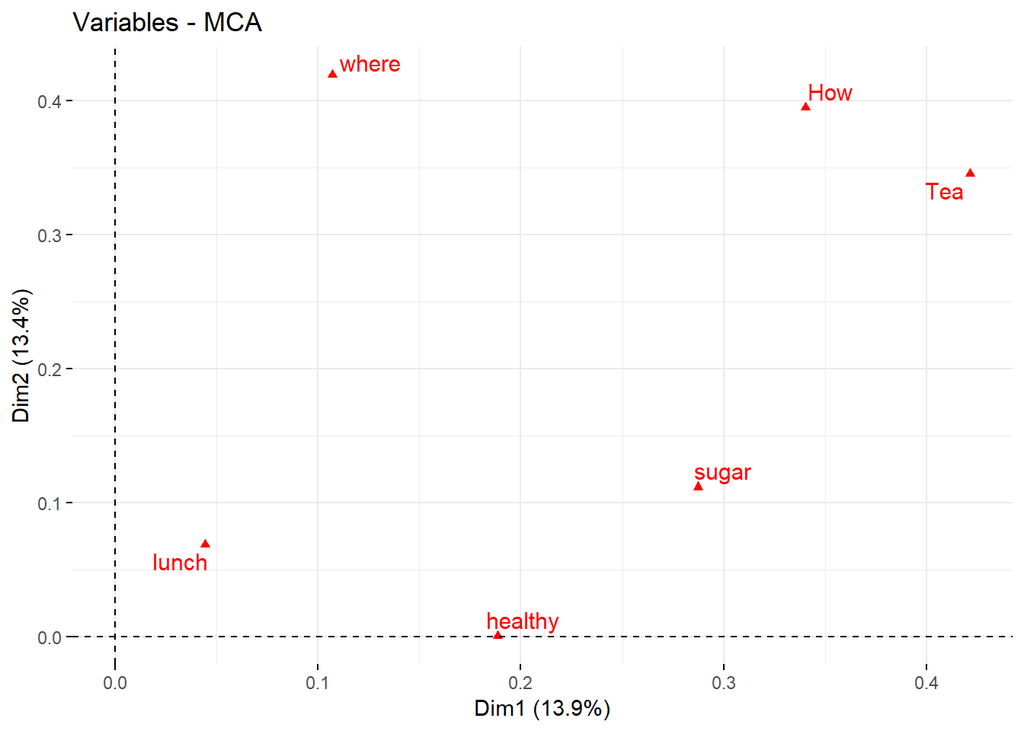

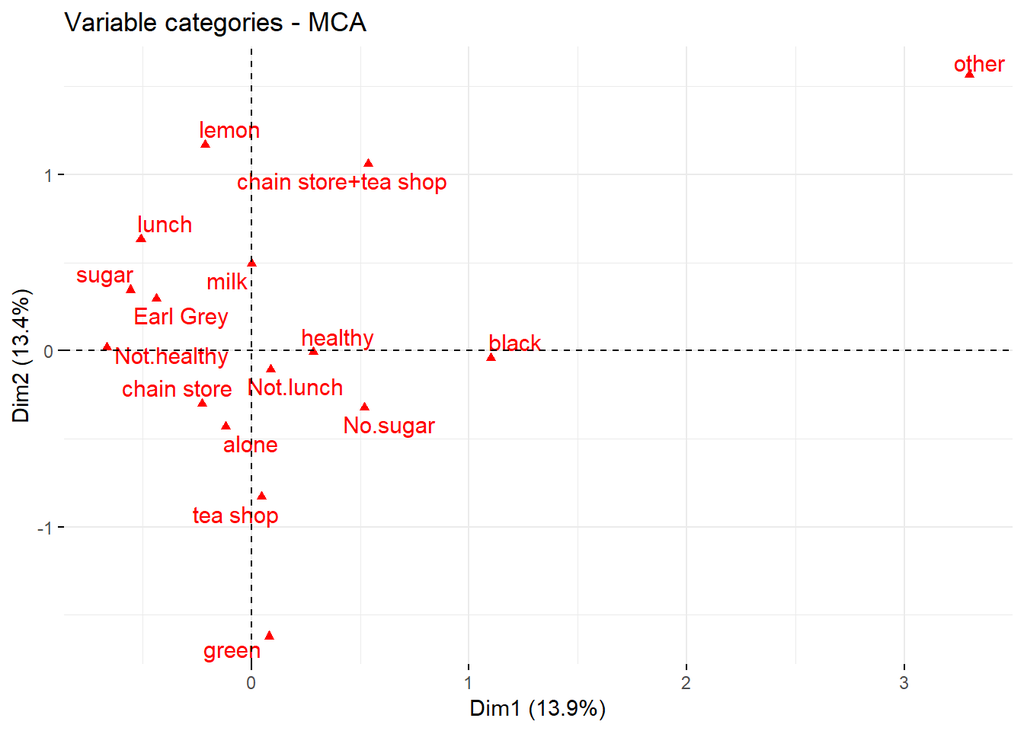

- The plot shows the variable to variable interaction. The variables that has similar profiles are placed together, for instance, milk, earl grey and sugar shares the similar profiles, thus, placed together. The variables who are negatively correlated are placed on the opposite quadrants in the plot.

**c. Color by cos2 values: quality on the factor map**

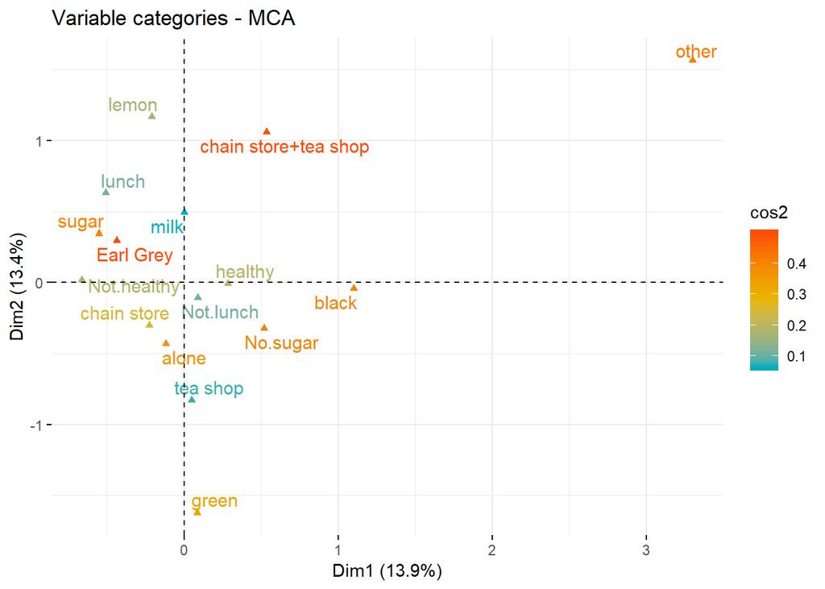

- Cos2 measures the degree of association between variable categories and a particular axis. The variable categories with high cos2 values are colored in red. The variable early grey and chain store + tea shop seems to have high cos2 values.

**d. Changing the transparency by cos2 values**

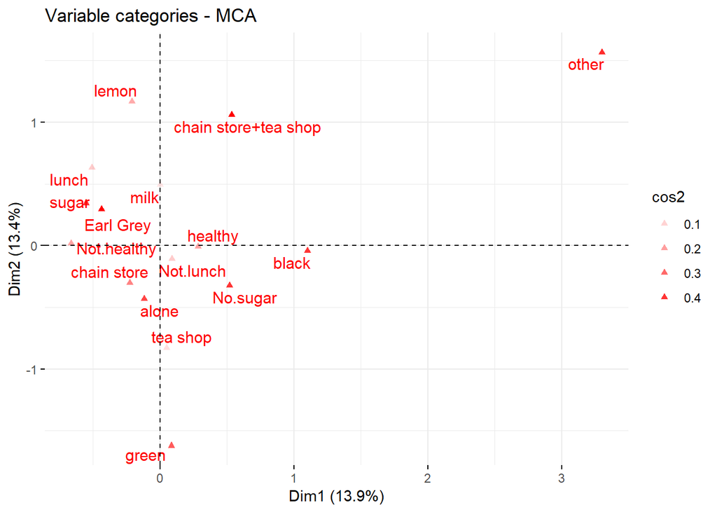

- Similar to the previous plot but the transparency changes with decreasing cos2 values. The triangle is red with early grey and chain store + tea shop and fading with the variables lemon, milk, healthy etc.

**e. Contributions of rows to dimension 1 and dimension 2**

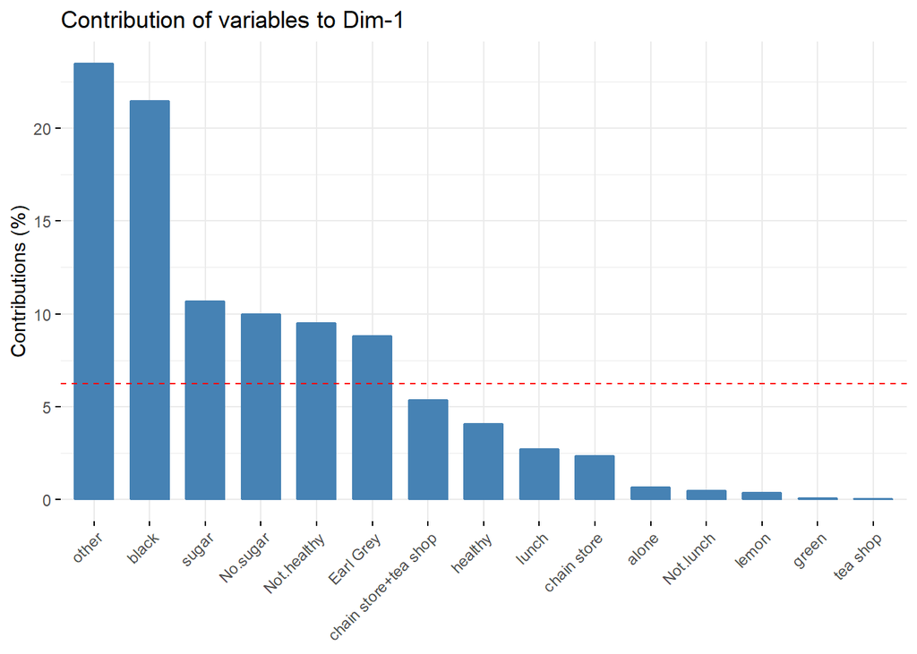

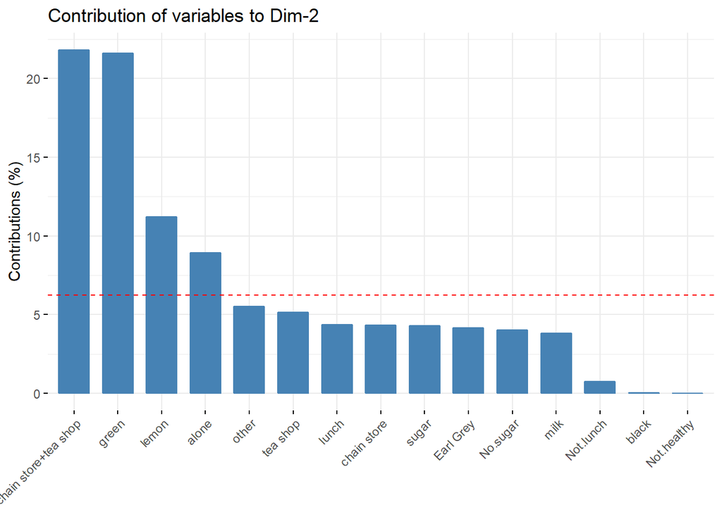

- The red dashed line as mentioned previously on the graph shows the expected average value when the contributions are consistent.
- The categories other and black tea contribute the most to Dim 1.
- Chain store + tea shop and green tea contribute the most to Dim 2.

**f. The most important variable categories highlighted in the scatter plot**

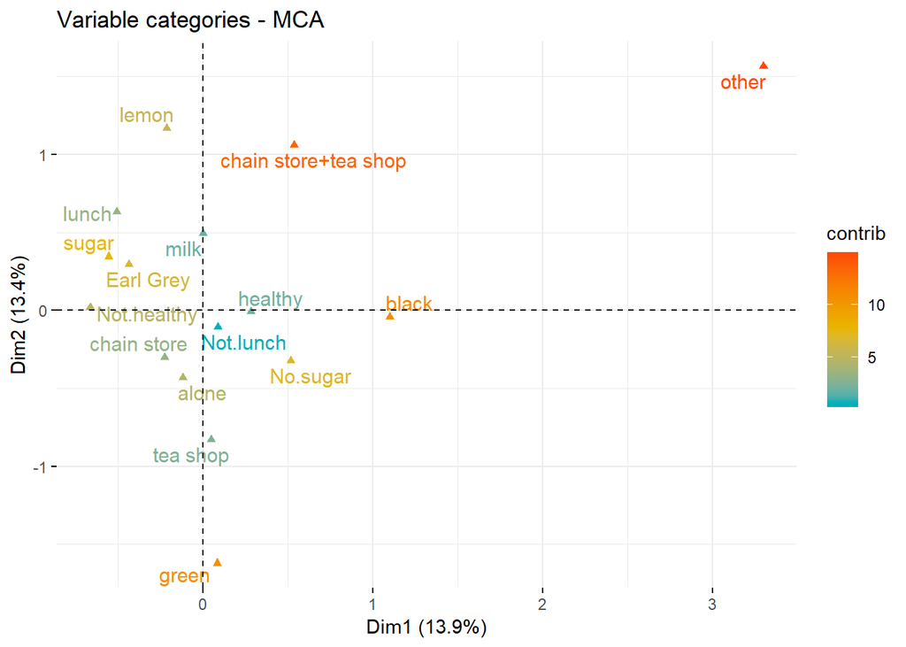

- The categories chain store + tea shop and other correspond to positive pole of Dim1 and sugar and earl grey corresponds to negative pole of Dim1.

**g. Biplot of variable analysis**

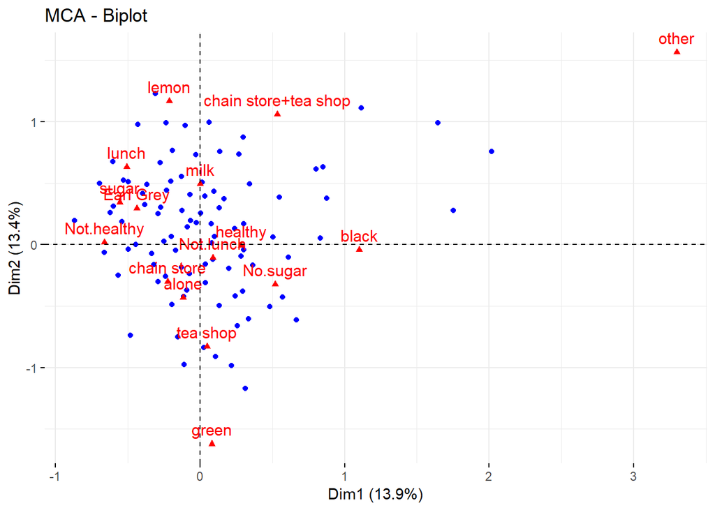

- Rows are represented by blue points and columns by red triangles. The rows and columns here corresponds to individuals and variable categories resp. The distance between them measure their similarity. The row and column points close to each other shares similar profile, for instance, the variable ‘chain store’ and ‘alone’ seems to share similar profile.

**h. Top 2 contributing variable categories in the tea dataset**

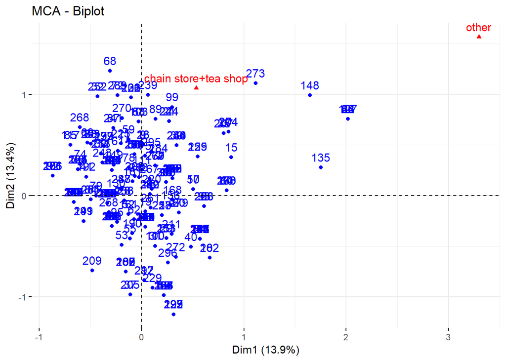

- The plot above displays the top 2 contributing variable categories in the tea dataset which are chain store + tea shop and others.

### **References**

http://hdr.undp.org/en/content/human-development-index-hdi

http://hdr.undp.org/sites/default/files/hdr2015_technical_notes.pdf

https://raw.githubusercontent.com/TuomoNieminen/Helsinki-Open-Data-Science/master/datasets/human_meta.txt

http://www.sthda.com/english/articles/31-principal-component-methods-in-r-practical-guide/114-mca-multiple-correspondence-analysis-in-r-essentials/